# chapter-3

Md Shaheen Kabir

2024-10-22

Loading the Libraries

```r
library(dplyr)
```

```r
library(ggplot2)
```

# Example - 01

```r
pig <- read.csv("data/paulsen.csv")
cats <- read.csv("data/cats.csv")
dim(pig)
```

```
## [1] 346   2
```

```r
sd(pig[, 1])
```

```
## [1] 100.0258
```

**Q-1.2 Calculate the sd of body weight for male and female cats**

```r
sd(cats$Bwt[cats$Sex == "M"])
```

```
## [1] 0.4674844
```

```r
sd(cats$Bwt[cats$Sex == "F"])
```

```
## [1] 0.2739879
```

**Q-1.3 Calculate the sd of heart weight for male and female cats**

```r
sd(cats$Hwt[cats$Sex == "M"])
```

```
## [1] 2.542288
```

```r
sd(cats$Hwt[cats$Sex == "F"])
```

```
## [1] 1.357666
```

**Q-1.4 Calculate the coefficient of variation for body weight for male and female cats**

```r
sd(cats$Bwt[cats$Sex == "M"])/mean(cats$Bwt[cats$Sex == "M"])
```

```
## [1] 0.1612015
```

```r
sd(cats$Bwt[cats$Sex == "F"])/mean(cats$Bwt[cats$Sex == "F"])
```

```
## [1] 0.1161175
```

**Q-1.5 Compare their sd and cv. What can you comment on them?**

```r
(sd(cats$Bwt[cats$Sex == "M"])/mean(cats$Bwt[cats$Sex == "M"]))>(sd(cats$Bwt[cats$Sex == "F"])/mean(cats$Bwt[cats$Sex == "F"]))
```

```
## [1] TRUE
```

# Example - 02

**Brains adult guinea pigs were sectioned and researchers measured the peak sponta neous current amplitude to decide whether current flows were multimodel which indicates that peak currents are combination of many smaller currents.** Download the data ‘paulsen.csv’ and copy it to your working directory  
Q-2.1 Read the file and store it in an object called ‘pig’

```r
pig <- read.csv("data/paulsen.csv")
dim(pig)
```

```
## [1] 346   2
```

**Q-2.2 How many columns does the data have?**

```r
dim(pig)
```

```
## [1] 346   2
```

**Q-2.3 Show the first few lines of the data on the console**

```r
head(pig)
```

```
##   X    y
## 1 1  8.7
## 2 2  9.1
## 3 3 14.1
## 4 4  8.1
## 5 5 16.2
## 6 6 12.2
```

**Q-2.4 How many guinea pigs they used in the study?**

```r
nrow(pig)
```

```
## [1] 346
```

**Q-2.5 Check the class of ‘pig’ object and class of its variable/s?**

```r
class(pig)
```

```
## [1] "data.frame"
```

```r
class(pig$y)
```

```
## [1] "numeric"
```

Q-2.6 Draw the histogram of measured observations; specify title, color, x axis label, y axis label, x axis range, y axis range and the number of intervals.  
Calculate the mean and median of the data, and add them as lines on to the plot.

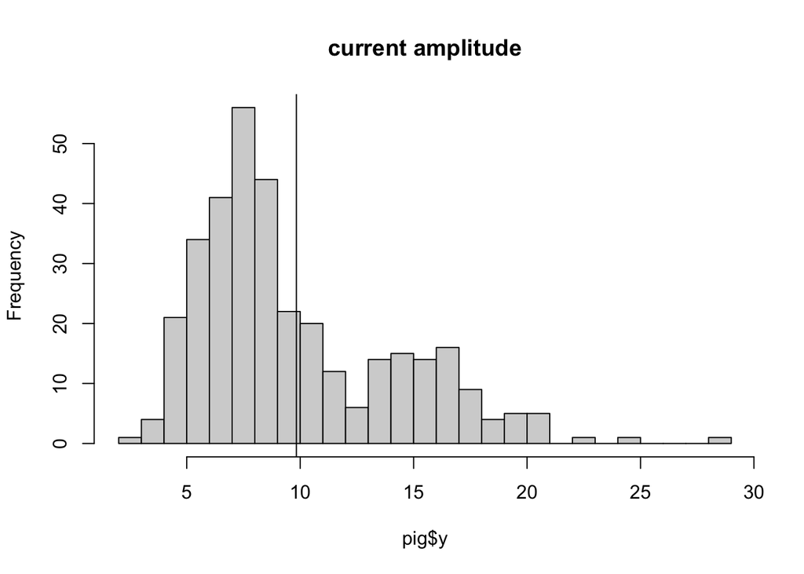

```r
hist(pig$y,
     main = "current amplitude",
     breaks = 20)
abline(v = mean(pig$y))
```

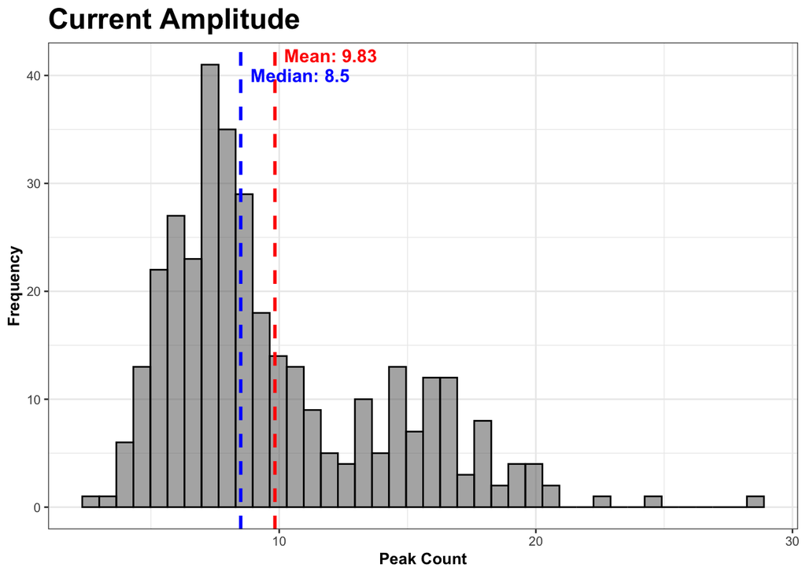

```r
# Histogram using ggplot
ggplot(pig, aes(x = y))+
  geom_histogram(color = 'black', alpha = 0.5, bins = 40)+
  labs( title = "Current Amplitude",
        x = "Peak Count",
        y = "Frequency")+
  theme_bw(base_size = 10)+
  theme(plot.title = element_text(size = 18, face = "bold"),
        axis.title = element_text(face = "bold"))+
  geom_vline(aes(xintercept = mean(y)), colour = 'red', linetype = 'dashed', size = 1)+
  geom_vline(aes(xintercept = median(y)), colour = 'blue', linetype = 'dashed', size = 1)+

  annotate("text", x = mean(pig$y), y = Inf, label = paste("Mean:", round(mean(pig$y), 2)),
           vjust = 1.5, hjust = -0.1, color = "red", size = 4, fontface = "bold") +
  annotate("text", x = median(pig$y), y = Inf, label = paste("Median:", round(median(pig$y), 2)),
           vjust = 3, hjust = -0.1, color = "blue", size = 4, fontface = "bold")
```

# Example - 03

Download the data ‘endangeredsp.csv’ and copy it to your working directory  
Q-3.1 Read the file and store it in an object called ‘endsp’  
Q-3.2 Show how many taxons there are

```r
endsp <- read.csv("data/endangeredsp.csv")
head(endsp)
```

```
##             X numberSpecies
## 1     Mammals            74
## 2       Birds            92
## 3    Reptiles            36
## 4  Amphibians            22
## 5        Fish           115
## 6 Crustaceans            21
```

```r
nrow(endsp)
```

```
## [1] 11
```

**Q-3.3 Draw the barplot of the data; specify title, color, category labels, x axis label, y axis label, y axis range**

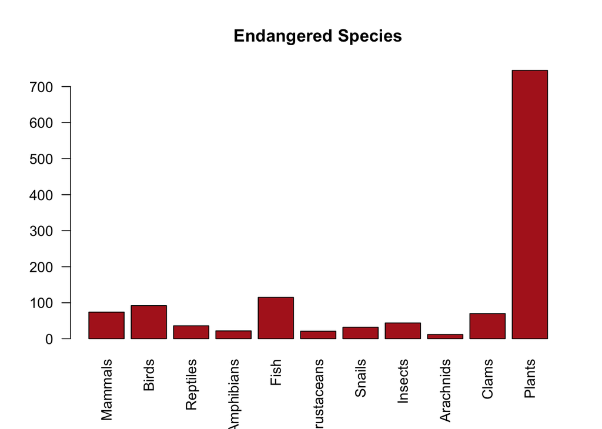

```r
barplot(endsp$numberSpecies,
        names.arg = endsp$X,
        las = 2,
        main = "Endangered Species",
        col = "firebrick")
```

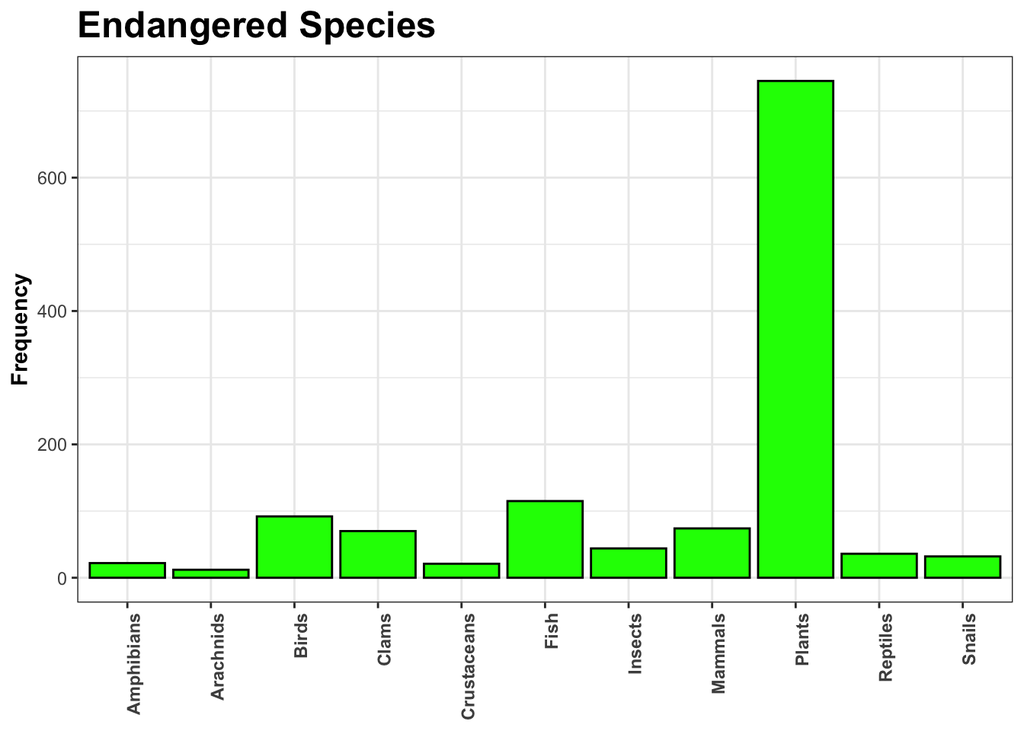

```r
# Barplot using ggplot
ggplot(endsp, aes(x = X, y = numberSpecies))+
  geom_bar(stat = "identity", color = "black", alpha = 1, fill = 'green')+
  labs(title = "Endangered Species",
       x = NULL,
       y = "Frequency")+
  theme_bw()+
  theme(plot.title = element_text(size = 18, face = 'bold'),
        axis.title = element_text(face = 'bold'),
        axis.text.x = element_text(angle = 90, hjust = 1 ,face = 'bold'))
```

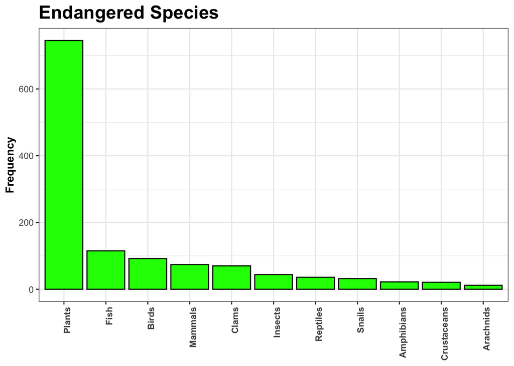

```r
# arrange in decreasing
ggplot(endsp, aes(x = reorder(X, numberSpecies, decreasing = T), y = numberSpecies))+
  geom_bar(stat = "identity", color = "black", alpha = 1, fill = 'green')+
  labs(title = "Endangered Species",
       x = NULL,
       y = "Frequency")+
  theme_bw()+
  theme(plot.title = element_text(size = 18, face = 'bold'),
        axis.title = element_text(face = 'bold'),
        axis.text.x = element_text(angle = 90, hjust = 1 ,face = 'bold'))
```

# Example - 04

```r
cats <- read.csv("data/cats.csv")
head(cats)
```

```
##   X Sex Bwt Hwt
## 1 1   F 2.0 7.0
## 2 2   F 2.0 7.4
## 3 3   F 2.0 9.5
## 4 4   F 2.1 7.2
## 5 5   F 2.1 7.3
## 6 6   F 2.1 7.6
```

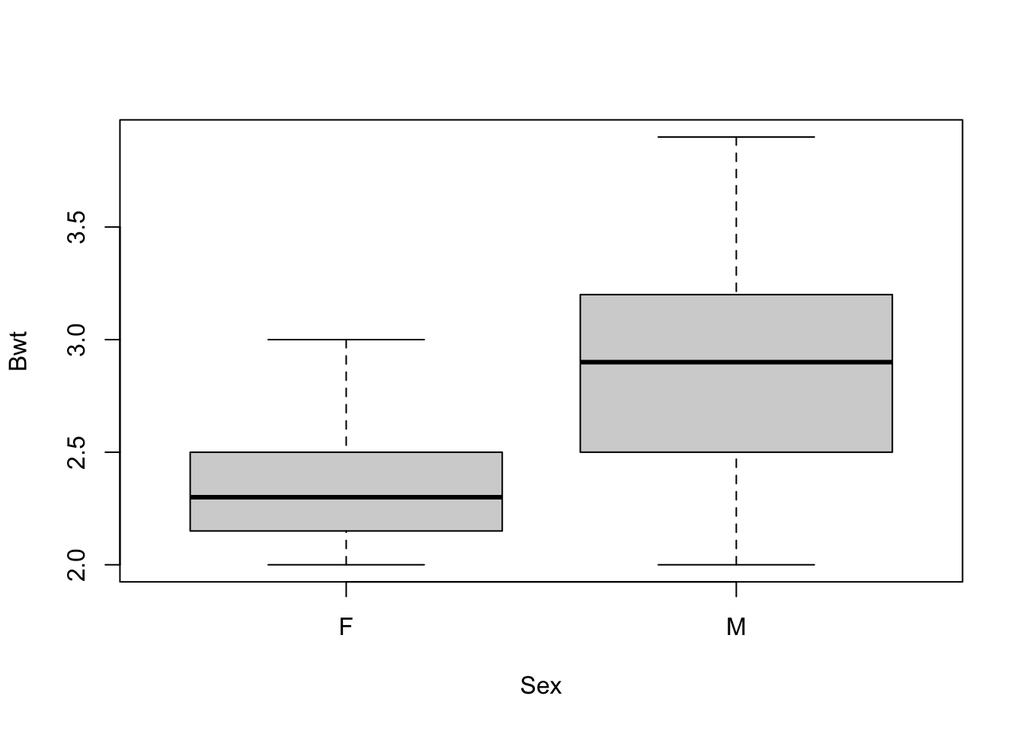

```r
boxplot(Bwt~Sex, data = cats)
```

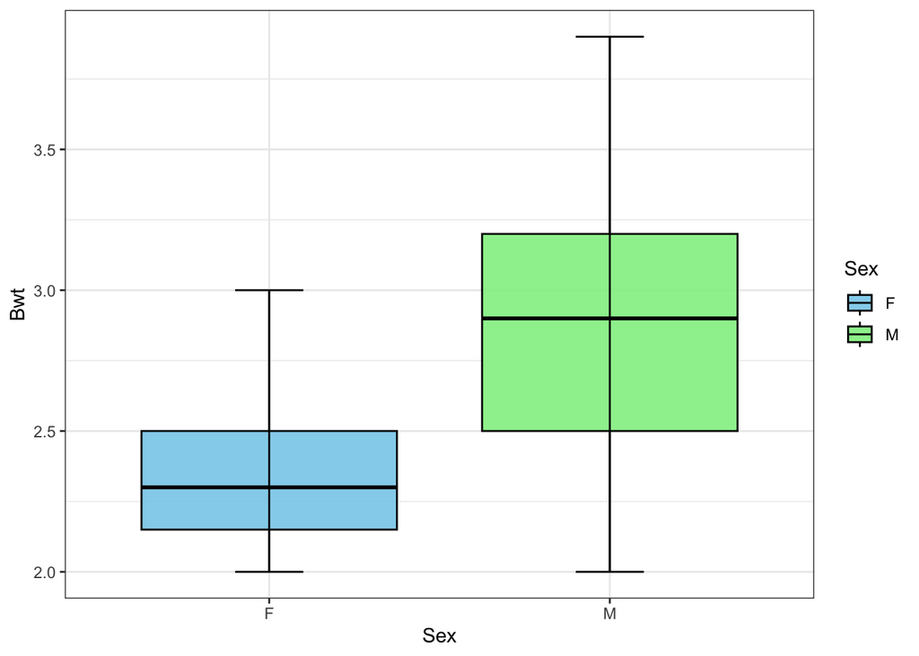

```r
cats$Sex <- factor(cats$Sex, levels = c("F", "M"))

# Body Weight boxplot using ggplot
ggplot(cats, aes(x = Sex, y = Bwt, fill = Sex))+
  geom_boxplot(color = 'black', alpha = 0.9, outlier.color = 'blue')+
  stat_boxplot(geom = 'errorbar', width = 0.2)+
  scale_fill_manual(values = c(F = 'skyblue',M = 'lightgreen'))+
  theme_bw()
```

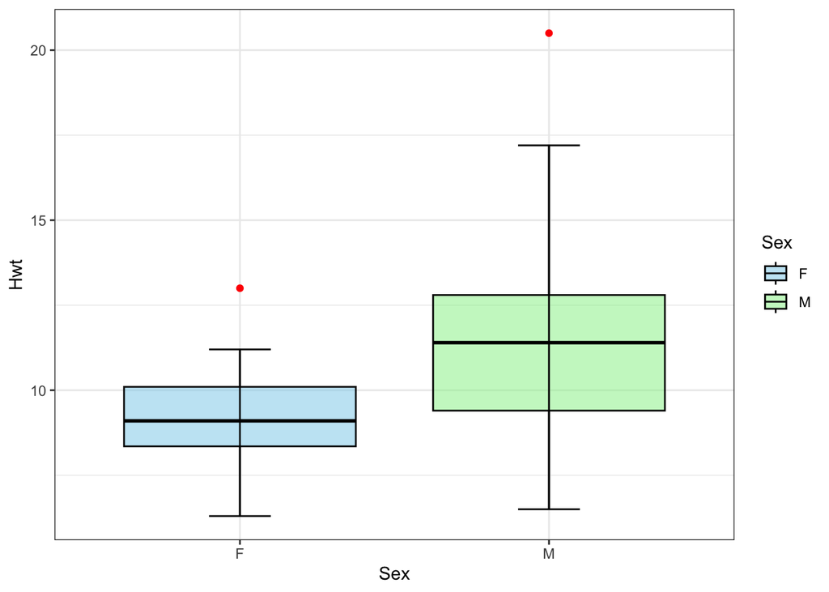

```r
# Heart Weight boxplot using ggplot
ggplot(cats, aes(x = Sex, y = Hwt, fill = Sex))+
  geom_boxplot(color = 'black', alpha = 0.5, outlier.color = "red", outlier.alpha = 1)+
  stat_boxplot(geom = 'errorbar', width = 0.2)+
  scale_fill_manual(values = c(F = 'skyblue', M = 'lightgreen'))+
  theme_bw()
```

# Example - 05

Draw the scatterplot of body weight (on x axis) vs heart weight (on y axis).  
Specify title, color, x axis label, y axis label, x axis range, y axis range, choose a type of point

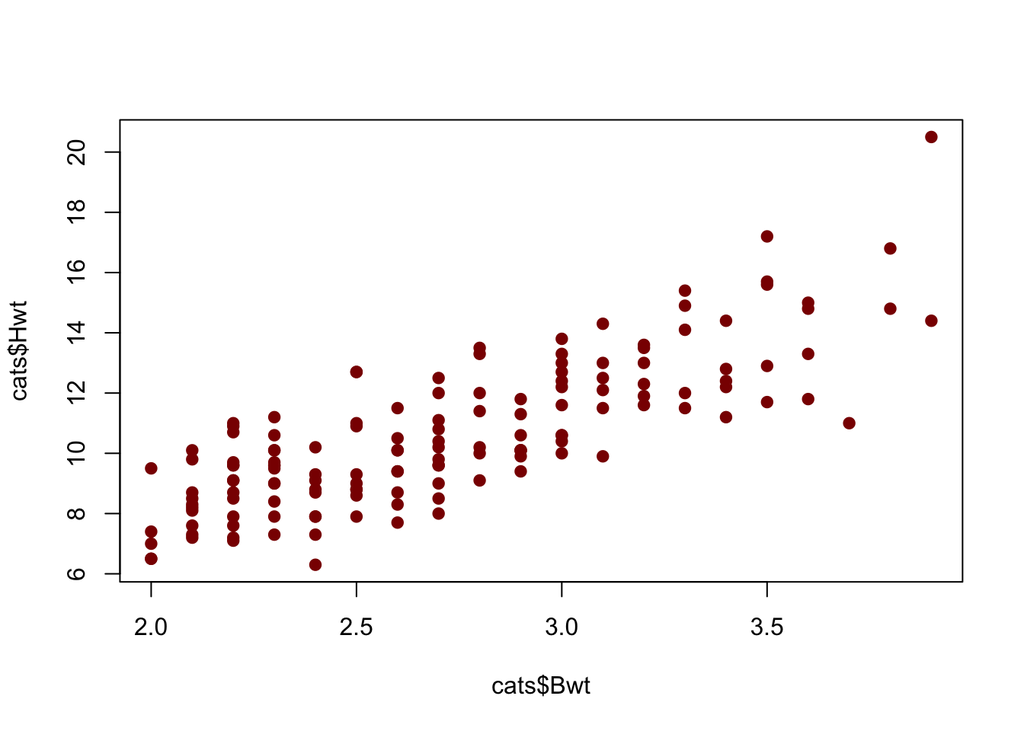

```r
plot(x = cats$Bwt, y = cats$Hwt, pch = 19, col = "darkred")
```

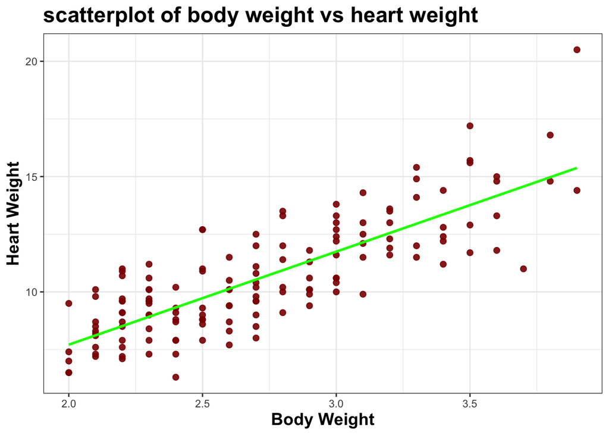

```r
# Scatterplot using ggplot
ggplot(cats, aes(x = Bwt, y = Hwt))+
  geom_point(color = 'darkred', alpha = 0.9, size = 2)+
  theme_bw()+
  labs(title = "scatterplot of body weight vs heart weight",
       x = "Body Weight",
       y = "Heart Weight")+
  theme(plot.title = element_text(size = 18, face = 'bold'),
        axis.title = element_text(size = 14,face = 'bold'))+
  geom_smooth(method = lm,se = F, linetype = 'solid', color = 'green')
```

# Exercise - 01

‘desertbird’ data contains the informatin about bird species living in desert. Each row is a bird species and the corresponding column is the number of individuals found in the desert for that species.  
**- Is the data numeric or categorical?**  
**- How many bird species are there in the data?**  
**- Which type of plot would you use to visualize the data?**  
**- Draw the appropriate plot of the data and specify the following arguments: x axis label, y axis label, title, color, labels, y axis range**

```r
desertbird <- read.csv("data/desertbird.csv")
head(desertbird)
```

```
##                  X abundance
## 1    Black Vulture        64
## 2   Turkey Vulture        23
## 3    Harris's Hawk         3
## 4  Red-tailed Hawk        16
## 5 American Kestrel         7
## 6   Gambel's Quail       148
```

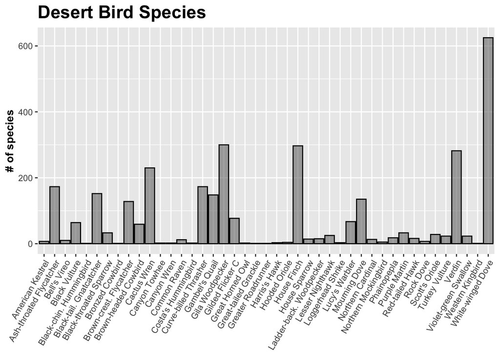

```r
ggplot(desertbird, aes(x = X, y = abundance))+
  geom_bar(stat = 'identity', color = 'black', alpha = 0.5)+
  labs(title = "Desert Bird Species",
       x = NULL,
       y = "# of species")+
  theme(axis.text.x = element_text(angle = 60, hjust = 1),
        plot.title = element_text(size = 18, face = 'bold'),
        axis.title.y = element_text(face = 'bold'))
```

# Exercise - 02

‘spideramputation’ data contains speeds of male spiders, before and after their one arm is amputated. In a sipder species, male spiders has been observed to voruntarily amputate one of their organs just before sexual maturity. The relevant question is that does males do this to increase their speed performance (because their weight will decrease) to find a female partner. To test the hypothesis, researchers recorded the speed of male spiders before and after one of their legs amputated.  
**- Draw an appropriate plot for the data and specify the following arguments: x axis label, y axis label, title, color, labels**  
**- By just looking at the graph, which group seems to have higher speed?**  
**- Calculate the mean and sd for both groups. We have to do a statistical analysis before jumping to any conclusion but by observing the plot and the the mean and sd values, what can you comment on the hypothesis?**

```r
spider <- read.csv("data/spider.csv", row.names = 1)
head(spider)
```

```
##   spider speed treatment
## 1      1  1.25    before
## 2      2  2.94    before
## 3      3  2.38    before
## 4      4  3.09    before
## 5      5  3.41    before
## 6      6  3.00    before
```

```r
summary(spider)
```

```
##      spider          speed        treatment
##  Min.   : 1.00   Min.   :1.250   Length:32
##  1st Qu.: 4.75   1st Qu.:2.730   Class :character
##  Median : 8.50   Median :3.195   Mode  :character
##  Mean   : 8.50   Mean   :3.261
##  3rd Qu.:12.25   3rd Qu.:3.527
##  Max.   :16.00   Max.   :5.450
```

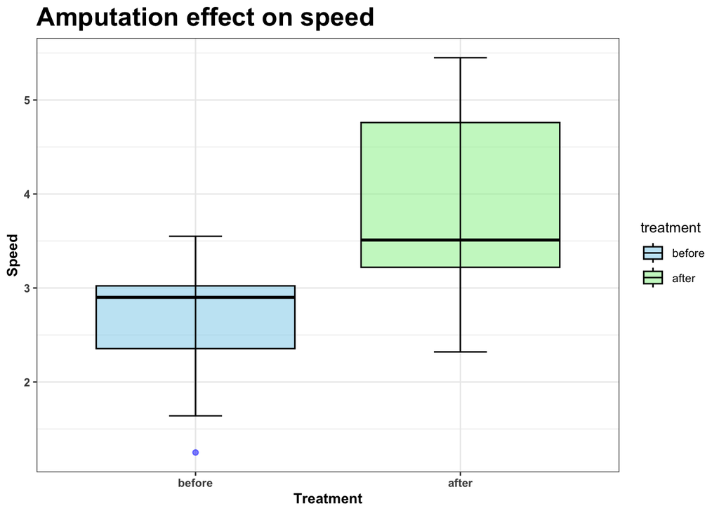

```r
spider$treatment <- factor(spider$treatment, levels = c("before", "after"))
ggplot(spider, aes(x = treatment, y = speed, fill = treatment))+
  geom_boxplot(color = 'black', alpha = 0.5, outlier.colour = 'blue')+
  stat_boxplot(geom = "errorbar", width = 0.2)+
  scale_fill_manual(values = c(before = 'skyblue', after = 'lightgreen'))+
  labs(title = "Amputation effect on speed",
       x = "Treatment",
       y = "Speed")+
  theme_bw(base_size = 10)+
  theme(plot.title = element_text(size = 18, face = "bold"),
        axis.title = element_text(face = "bold"),
        axis.text = element_text(face = "bold"))
```

# Exercise - 03

```r
data(cars)
head(cars)
```

```
##   speed dist
## 1     4    2
## 2     4   10
## 3     7    4
## 4     7   22
## 5     8   16
## 6     9   10
```

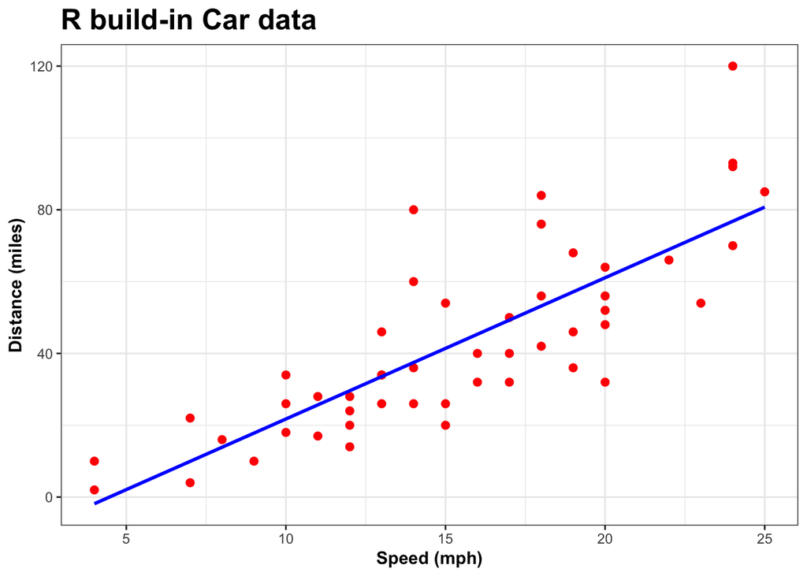

```r
ggplot(cars, aes(x = speed, y = dist))+
  geom_point(color = 'red', size = 2)+
  geom_smooth(method = "lm", se = F, color = 'blue')+
  labs(title = "R build-in Car data",
       x = "Speed (mph)",
       y = "Distance (miles)")+
  theme_bw()+
  theme(plot.title = element_text(size = 18, face = 'bold'),
        axis.title = element_text(face = "bold"))
```

# Exercise - 04

```r
data("DNase")
head(DNase)
```

```
## Grouped Data: density ~ conc | Run
##   Run       conc density
## 1   1 0.04882812   0.017
## 2   1 0.04882812   0.018
## 3   1 0.19531250   0.121
## 4   1 0.19531250   0.124
## 5   1 0.39062500   0.206
## 6   1 0.39062500   0.215
```

```r
dnase.r3 <- subset(DNase, Run == 3, select = c(conc, density))
dnase.r5 <- subset(DNase, Run == 5, select = c(conc, density))
dnase.r8 <- subset(DNase, Run == 8, select = c(conc, density))
dnase.r11 <- subset(DNase, Run == 11, select = c(conc, density))
```

**Combining in data.frame object**

```r
dnase.combined <- rbind(
  data.frame(conc = dnase.r3$conc, density = dnase.r3$density, replicate = "ELISA Assay Run 3"),
  data.frame(conc = dnase.r5$conc, density = dnase.r5$density, replicate = "ELISA Assay Run 5"),
  data.frame(conc = dnase.r8$conc, density = dnase.r8$density, replicate = "ELISA Assay Run 8"),
  data.frame(conc = dnase.r11$conc, density = dnase.r11$density, replicate = "ELISA Assay Run 11")
)
```

**Plotting the scatterplot**

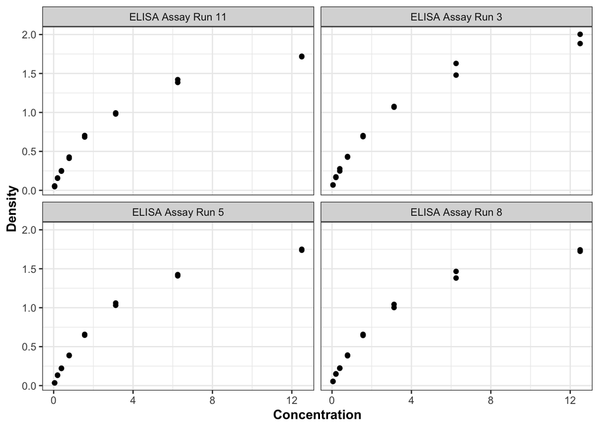

```r
ggplot(dnase.combined, aes(x = conc, y = density))+
  geom_point()+
  facet_wrap(~replicate, nrow = 2, ncol = 2)+
  labs(title = NULL,
       x = "Concentration",
       y = "Density")+
  theme_bw()+
  theme(axis.title = element_text(face = 'bold'))
```

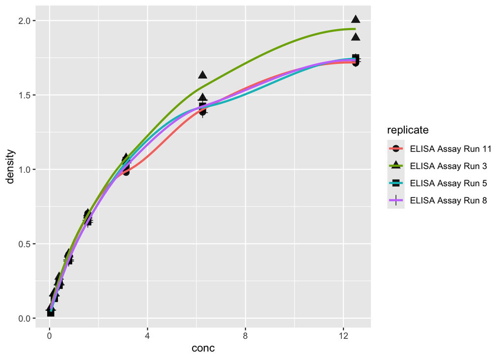

```r
ggplot(dnase.combined, aes(x = conc, y = density, fill = replicate, shape = replicate))+
  geom_point(size = 3, alpha = 0.9)+
  geom_smooth(method = 'loess', aes(color = replicate), se = F, linetype = 'solid')
```

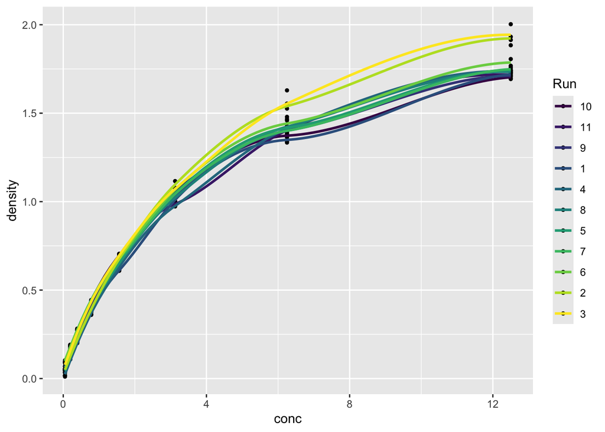

```r
ggplot(DNase, aes(x = conc, y = density, fill = Run))+
  geom_point(size = 1, alpha = 1)+
  geom_smooth(aes(color = Run), method = "loess", se = F, linetype = 'solid')
```

**coploting all the 11 sample in one window.**

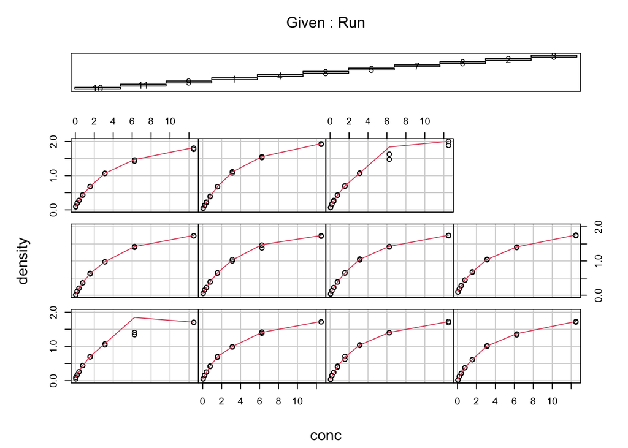

```r
coplot(density ~ conc | Run, data = DNase, panel = panel.smooth)
```